# machine learning course project

# An analysis of the weight lifting exercises dataset

## Summary

This document describes analysis done for the final assigment of the Coursera Practical Machine Learning class. The task of the project was to predict how well subjects performed weight lifting excercises based on data collected form accelerometers attached to the person performing the exercises. The dataset cantains data from six different people and outcome was classified into 5 different categories. Our task is to predict classe of excercise based on accelerometers data. Also in course project there is testing dataset with 20 samples and there is quiz, which checks prediction results of testing set.

## Setup

### Load data

First of all, we load necessary libs and two datasets. In testing dataset there are many NA values. Also in testing set there are “#DIV/0!” values and they also replaced by NA

```r
library(dplyr)
library(caret)
library(corrplot)
library(scales)
library(doParallel)
set.seed(12345)

url <- "https://d396qusza40orc.cloudfront.net/predmachlearn/pml-training.csv" ;
trainfile <-"pml-training.csv"
if( !file.exists(trainfile) ) download.file( url, trainfile, quiet=TRUE)
traindataset<-read.csv(trainfile,na.strings=c(""," ","NA","#DIV/0!"))
url <- "https://d396qusza40orc.cloudfront.net/predmachlearn/pml-testing.csv" ;
testfile <-"pml-testing.csv"
if( !file.exists(testfile) ) download.file( url, testfile, quiet=TRUE)
testdataset<-read.csv(testfile,na.strings=c(""," ","NA","#DIV/0!"))
```

### Data cleaning

In our testing dataset there are many NA values, so before doing any machine learning algorithm we cleaned our data.

```r
nrow(traindataset)
```

```
## [1] 19622
```

```r
na_count <-sapply(traindataset, function(y) sum(length(which(is.na(y)))))
na_count <- data.frame(na_count)
na_count$column <-row.names(na_count)
na_count<-arrange(na_count,-na_count)
unique(na_count$na_count)
```

```
##  [1] 19622 19301 19300 19299 19296 19294 19293 19248 19227 19226 19225
## [12] 19221 19220 19218 19217 19216     0
```

As we can see there are columns with more than 97% of NA in it. So we exclude it from our dataset. Also first 7 columns contains description of the current sample, not the sample data, so we also exclude this columns (number, user_name, time info and windows info)

```r
traindataset_sub<-dplyr::select(traindataset,-c(1,2,3,4,5,6,7,one_of(na_count[na_count$na_count>0,2])))
table(is.na(traindataset_sub))
```

```
##
##   FALSE
## 1039966
```

### Data check

Also before machine learning we checked data on correlation. This step reduces count of predictors.

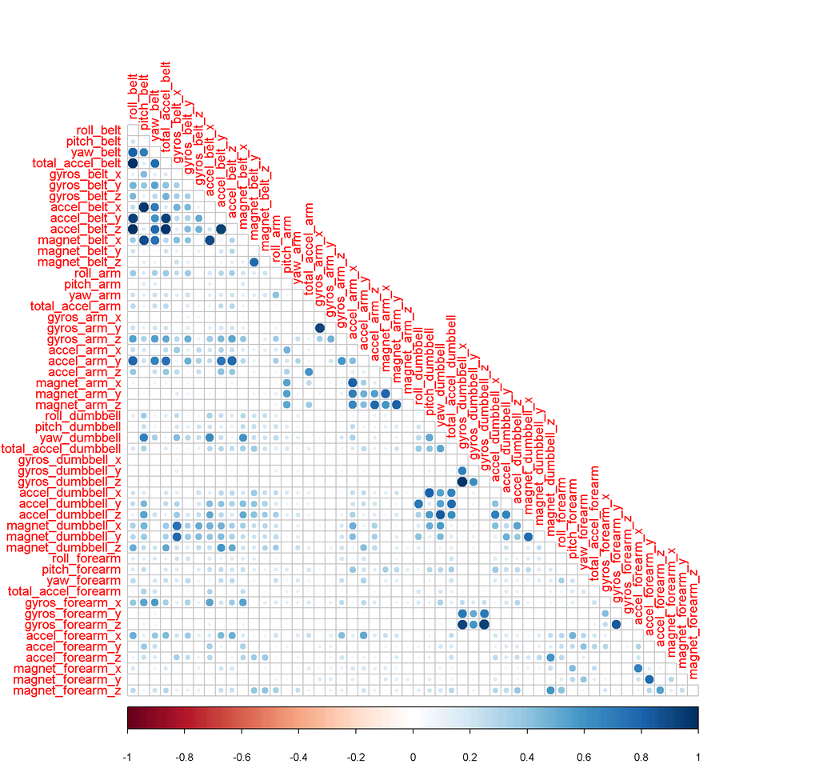

```r
traindataset_sub_num  <- data.frame(lapply(traindataset_sub[,-ncol(traindataset_sub)], function (x) as.numeric(x)))
traincorr<-abs(cor(traindataset_sub_num))
diag(traincorr) <-0
corrplot(traincorr,type = "lower")
```

```r
highlycorr <-findCorrelation(traincorr,cutoff = 0.8)
traindataset_sub<-traindataset_sub[,-highlycorr]
```

## Machine learning

```r
inTrain <- createDataPartition(y=traindataset_sub$class,p=0.75,list=F)
train_sample <- traindataset_sub[inTrain,]
test_sample <- traindataset_sub[-inTrain,]
```

When we performed two machine learning algorithms: LDA and random forest.

```r
cl <- makeCluster(detectCores())
registerDoParallel(cl)
tc = trainControl(method = "cv",number = 10)

modrf <- train(classe~.,method = "rf",train_sample,trControl = tc, allowParallel = TRUE )
modlda <- train(classe~.,method = "lda",train_sample)
stopCluster(cl)
```

When we look at our in nd out of sample errors:

```r
predrf<-predict(modrf,test_sample)
confusionMatrix(predrf,test_sample$classe)
```

```
## Confusion Matrix and Statistics
##
##           Reference
## Prediction    A    B    C    D    E
##          A 1394    6    0    0    0
##          B    1  937    3    0    0
##          C    0    6  847    7    2
##          D    0    0    5  797    4
##          E    0    0    0    0  895
##
## Overall Statistics
##
##                Accuracy : 0.9931
##                  95% CI : (0.9903, 0.9952)
##     No Information Rate : 0.2845
##     P-Value [Acc > NIR] : < 2.2e-16
##
##                   Kappa : 0.9912
##  Mcnemar's Test P-Value : NA
##
## Statistics by Class:
##
##                      Class: A Class: B Class: C Class: D Class: E
## Sensitivity            0.9993   0.9874   0.9906   0.9913   0.9933
## Specificity            0.9983   0.9990   0.9963   0.9978   1.0000
## Pos Pred Value         0.9957   0.9957   0.9826   0.9888   1.0000
## Neg Pred Value         0.9997   0.9970   0.9980   0.9983   0.9985
## Prevalence             0.2845   0.1935   0.1743   0.1639   0.1837
## Detection Rate         0.2843   0.1911   0.1727   0.1625   0.1825
## Detection Prevalence   0.2855   0.1919   0.1758   0.1644   0.1825
## Balanced Accuracy      0.9988   0.9932   0.9935   0.9945   0.9967
```

```r
predrftrain<-predict(modrf,train_sample)
confusionMatrix(predrftrain,train_sample$classe)
```

```
## Confusion Matrix and Statistics
##
##           Reference
## Prediction    A    B    C    D    E
##          A 4185    0    0    0    0
##          B    0 2848    0    0    0
##          C    0    0 2567    0    0
##          D    0    0    0 2412    0
##          E    0    0    0    0 2706
##
## Overall Statistics
##
##                Accuracy : 1
##                  95% CI : (0.9997, 1)
##     No Information Rate : 0.2843
##     P-Value [Acc > NIR] : < 2.2e-16
##
##                   Kappa : 1
##  Mcnemar's Test P-Value : NA
##
## Statistics by Class:
##
##                      Class: A Class: B Class: C Class: D Class: E
## Sensitivity            1.0000   1.0000   1.0000   1.0000   1.0000
## Specificity            1.0000   1.0000   1.0000   1.0000   1.0000
## Pos Pred Value         1.0000   1.0000   1.0000   1.0000   1.0000
## Neg Pred Value         1.0000   1.0000   1.0000   1.0000   1.0000
## Prevalence             0.2843   0.1935   0.1744   0.1639   0.1839
## Detection Rate         0.2843   0.1935   0.1744   0.1639   0.1839
## Detection Prevalence   0.2843   0.1935   0.1744   0.1639   0.1839
## Balanced Accuracy      1.0000   1.0000   1.0000   1.0000   1.0000
```

```r
predlda<-predict(modlda,test_sample)
confusionMatrix(predlda,test_sample$classe)
```

```
## Confusion Matrix and Statistics
##
##           Reference
## Prediction    A    B    C    D    E
##          A 1064  180   94   33   61
##          B  116  540   77   78  156
##          C  135  104  567  106  106
##          D   62   57   92  516  100
##          E   18   68   25   71  478
##
## Overall Statistics
##
##                Accuracy : 0.6454
##                  95% CI : (0.6318, 0.6588)
##     No Information Rate : 0.2845
##     P-Value [Acc > NIR] : < 2.2e-16
##
##                   Kappa : 0.5512
##  Mcnemar's Test P-Value : < 2.2e-16
##
## Statistics by Class:
##
##                      Class: A Class: B Class: C Class: D Class: E
## Sensitivity            0.7627   0.5690   0.6632   0.6418  0.53052
## Specificity            0.8951   0.8920   0.8886   0.9241  0.95453
## Pos Pred Value         0.7430   0.5584   0.5570   0.6239  0.72424
## Neg Pred Value         0.9047   0.8961   0.9259   0.9294  0.90033
## Prevalence             0.2845   0.1935   0.1743   0.1639  0.18373
## Detection Rate         0.2170   0.1101   0.1156   0.1052  0.09747
## Detection Prevalence   0.2920   0.1972   0.2076   0.1686  0.13458
## Balanced Accuracy      0.8289   0.7305   0.7759   0.7830  0.74253
```

```r
predldatrain<-predict(modlda,train_sample)
confusionMatrix(predldatrain,train_sample$classe)
```

```
## Confusion Matrix and Statistics
##
##           Reference
## Prediction    A    B    C    D    E
##          A 3152  484  281  137  146
##          B  374 1656  242  195  488
##          C  357  296 1645  308  329
##          D  235  184  319 1612  263
##          E   67  228   80  160 1480
##
## Overall Statistics
##
##                Accuracy : 0.6485
##                  95% CI : (0.6407, 0.6562)
##     No Information Rate : 0.2843
##     P-Value [Acc > NIR] : < 2.2e-16
##
##                   Kappa : 0.5556
##  Mcnemar's Test P-Value : < 2.2e-16
##
## Statistics by Class:
##
##                      Class: A Class: B Class: C Class: D Class: E
## Sensitivity            0.7532   0.5815   0.6408   0.6683   0.5469
## Specificity            0.9005   0.8906   0.8938   0.9187   0.9555
## Pos Pred Value         0.7505   0.5604   0.5605   0.6169   0.7345
## Neg Pred Value         0.9018   0.8987   0.9218   0.9339   0.9035
## Prevalence             0.2843   0.1935   0.1744   0.1639   0.1839
## Detection Rate         0.2142   0.1125   0.1118   0.1095   0.1006
## Detection Prevalence   0.2854   0.2008   0.1994   0.1775   0.1369
## Balanced Accuracy      0.8268   0.7360   0.7673   0.7935   0.7512
```

As we can see random forest model have very good accuracy and Sensitivity and Specificity for all classes for test and train sample, so our model is not overfitted for train dataset. Lets look on variable importance plot

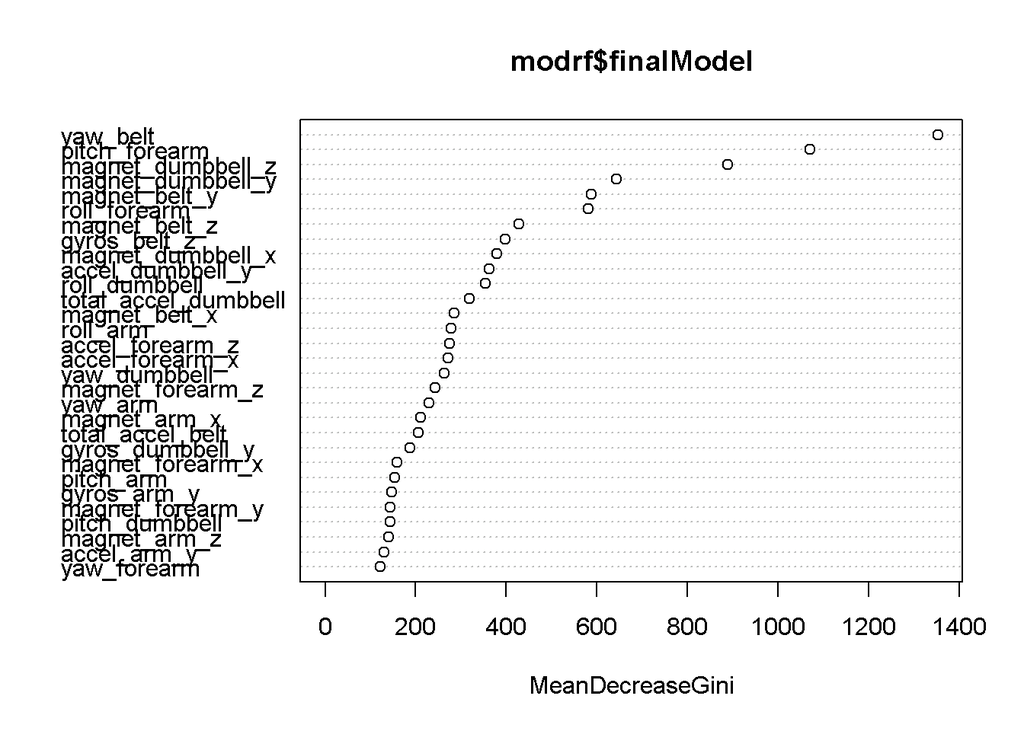

```r
varImpPlot(modrf$finalModel)
```

## Test sample prediction

Then we perform prediction to on our test samples. It performs 20/20 on Course project quiz, so our model is quite good.

```r
predrftest<-predict(modrf,testdataset)
predrftest
```

```
##  [1] B A B A A E D B A A B C B A E E A B B B
## Levels: A B C D E
```